# Living alone

# 1 Description of DataSchema variable

The description of harmonised variable is the following:

- Short name: `living_alone`
- Variable label: `Participant is currently living alone`
- Variable description: `Participant is currently living alone`
- Domain: `Socio-demographic and economic characteristics`
- Value type: `categorical`
- Category coding:

| **Code** | **Category Label** |
| --- | --- |
| 0 | No |
| 1 | Yes |

- Category missings:

| **Code** | **Category Label** |
| --- | --- |
| 991 | CAPI/interviewer error |
| 992 | Impute |
| 993 | Disable to measure |
| 994 | Not attempt/not done |
| 995 | Does not answer |
| 996 | Not applicable |
| 997 | Refuse |
| 998 | Do not know |
| 999 | Missing |

# 2 Data process

## 2.1 ELSA

### 2.1.1 Wave 1

#### 2.1.1.1 Study-specific variable description

| **Name** | `npeople` |
| --- | --- |
| **Label** | `number of people in HH (adults + children)` |
| **Table name** | `wave_1_ifs_derived_variables` |
| **Description** |  |

NPEOPLE

| Sample size | Missing values |
| --- | --- |
| 12099 | 0 |

Category

|  | 1 | 2 | 3 | 4 | 5 | 6 | 7 | 8 | 9 | 10 | 11 |
| --- | --- | --- | --- | --- | --- | --- | --- | --- | --- | --- | --- |
| Frequency | 2850.00 | 6664.00 | 1552.00 | 764.00 | 183.00 | 68.00 | 8.00 | 4.00 | 2.00 | 3.00 | 1.00 |
| Percentage | 23.56 | 55.08 | 12.83 | 6.31 | 1.51 | 0.56 | 0.07 | 0.03 | 0.02 | 0.02 | 0.01 |

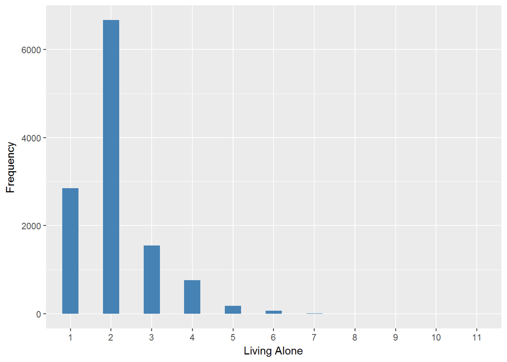

#### 2.1.1.2 Harmonisation algorithm

To compute the harmonized variable from the study-specific variable it has to be recoded as follows:

- `keep 1 into 1`
- `>1 into 0`
- `NA into 999`

**R script:**

```r
ELSA_ds_w1 <- tibble(id = ELSA_w1_la$id)
ELSA_ds_w1$living_alone <- car::recode(ELSA_w1_la$npeople, "2:hi=0 ;NA=999")
ELSA_ds_w1$living_alone <- labelled(ELSA_ds_w1$living_alone, labels = c(No = 0,
    Yes = 1, Missing = 999, `Do not know` = 998, Refuse = 997, `Not attempt not done` = 994,
    `Does not answer` = 995, `Not applicable` = 996, `Disable to measure` = 993,
    Impute = 992, `CAPI interviewer error` = 991))
```

#### 2.1.1.3 Statistics of the new harmonised variable

| Sample size | Missing values |
| --- | --- |
| 12099 | 0 |

Category

|  | 0 | 1 |
| --- | --- | --- |
| Frequency | 9249.00 | 2850.00 |
| Percentage | 76.44 | 23.56 |

Type of missing

|  | 991 | 992 | 993 | 994 | 995 | 996 | 997 | 998 | 999 | NA |
| --- | --- | --- | --- | --- | --- | --- | --- | --- | --- | --- |
| Frequency | 0 | 0 | 0 | 0 | 0 | 0 | 0 | 0 | 0 | 0 |
| Percentage | 0 | 0 | 0 | 0 | 0 | 0 | 0 | 0 | 0 | 0 |

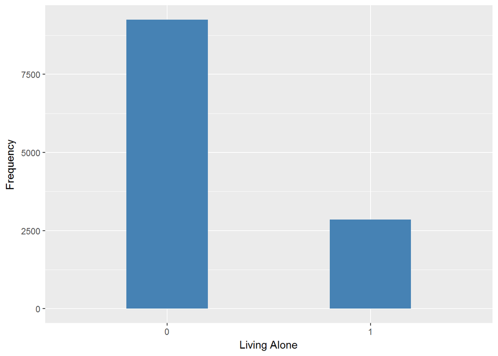

#### 2.1.1.4 Validation

|  | >=2->0 | 1 |
| --- | --- | --- |
| BeforeH | 9249 | 2850 |
| AfterH | 9249 | 2850 |

### 2.1.2 Wave 2

#### 2.1.2.1 Study-specific variable description

| **Name** | `npeople` |
| --- | --- |
| **Label** | `number of people in HH (adults + children)` |
| **Table name** | `wave_2_ifs_derived_variables` |
| **Description** |  |

NPEOPLE

| Sample size | Missing values |
| --- | --- |
| 9432 | 0 |

Category

|  | 1 | 2 | 3 | 4 | 5 | 6 | 7 | 8 | 10 | 11 |
| --- | --- | --- | --- | --- | --- | --- | --- | --- | --- | --- |
| Frequency | 2333.00 | 5371.00 | 1124.00 | 422.00 | 127.00 | 44.00 | 7.00 | 2.00 | 1.00 | 1.00 |
| Percentage | 24.73 | 56.94 | 11.92 | 4.47 | 1.35 | 0.47 | 0.07 | 0.02 | 0.01 | 0.01 |

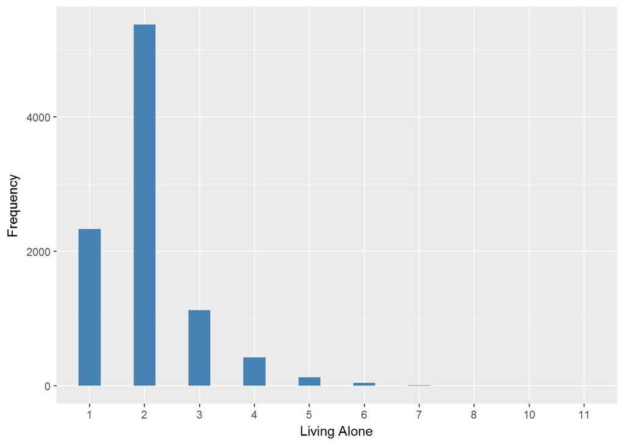

#### 2.1.2.2 Harmonisation algorithm

To compute the harmonized variable from the study-specific variable it has to be recoded as follows:

- `keep 1 into 1`
- `>1 into 0`
- `NA into 999`

**R script:**

```r
ELSA_ds_w2 <- tibble(id = ELSA_w2_la$id)
ELSA_ds_w2$living_alone <- car::recode(ELSA_w2_la$npeople, "2:hi=0 ;NA=999")
ELSA_ds_w2$living_alone <- labelled(ELSA_ds_w2$living_alone, labels = c(No = 0,
    Yes = 1, Missing = 999, `Do not know` = 998, Refuse = 997, `Not attempt not done` = 994,
    `Does not answer` = 995, `Not applicable` = 996, `Disable to measure` = 993,
    Impute = 992, `CAPI interviewer error` = 991))
```

#### 2.1.2.3 Statistics of the new harmonised variable

| Sample size | Missing values |
| --- | --- |
| 9432 | 0 |

Category

|  | 0 | 1 |
| --- | --- | --- |
| Frequency | 7099.00 | 2333.00 |
| Percentage | 75.27 | 24.73 |

Type of missing

|  | 991 | 992 | 993 | 994 | 995 | 996 | 997 | 998 | 999 | NA |
| --- | --- | --- | --- | --- | --- | --- | --- | --- | --- | --- |
| Frequency | 0 | 0 | 0 | 0 | 0 | 0 | 0 | 0 | 0 | 0 |
| Percentage | 0 | 0 | 0 | 0 | 0 | 0 | 0 | 0 | 0 | 0 |

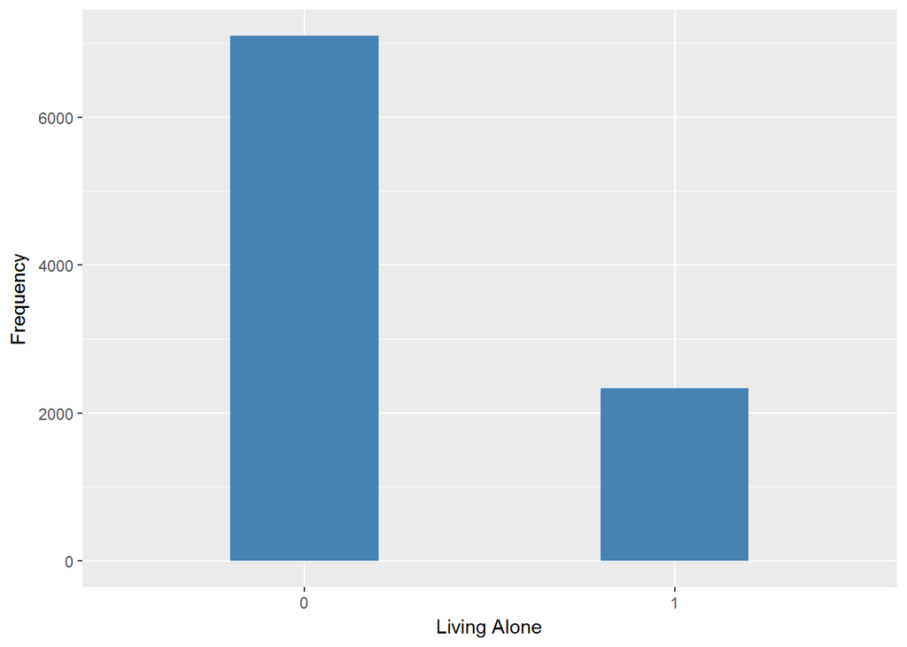

#### 2.1.2.4 Validation

|  | >=2->0 | 1 |
| --- | --- | --- |
| BeforeH | 7099 | 2333 |
| AfterH | 7099 | 2333 |

### 2.1.3 Wave 3

#### 2.1.3.1 Study-specific variable description

| **Name** | `npeople` |
| --- | --- |
| **Label** | `number of people in HH (adults + children)` |
| **Table name** | `wave_3_ifs_derived_variables` |
| **Description** |  |

NPEOPLE

| Sample size | Missing values |
| --- | --- |
| 9771 | 0 |

Category

|  | 1 | 2 | 3 | 4 | 5 | 6 | 7 | 8 | 10 | 11 |
| --- | --- | --- | --- | --- | --- | --- | --- | --- | --- | --- |
| Frequency | 2295.00 | 5215.00 | 1321.00 | 650.00 | 211.00 | 61.00 | 10.0 | 2.00 | 1.00 | 5.00 |
| Percentage | 23.49 | 53.37 | 13.52 | 6.65 | 2.16 | 0.62 | 0.1 | 0.02 | 0.01 | 0.05 |

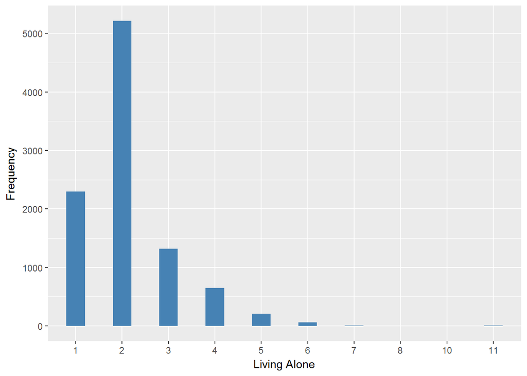

#### 2.1.3.2 Harmonisation algorithm

To compute the harmonized variable from the study-specific variable it has to be recoded as follows:

- `keep 1 into 1`
- `>1 into 0`
- `NA into 999`

**R script:**

```r
ELSA_ds_w3 <- tibble(id = ELSA_w3_la$id)
ELSA_ds_w3$living_alone <- car::recode(ELSA_w3_la$npeople, "2:hi=0 ;NA=999")
ELSA_ds_w3$living_alone <- labelled(ELSA_ds_w3$living_alone, labels = c(No = 0,
    Yes = 1, Missing = 999, `Do not know` = 998, Refuse = 997, `Not attempt not done` = 994,
    `Does not answer` = 995, `Not applicable` = 996, `Disable to measure` = 993,
    Impute = 992, `CAPI interviewer error` = 991))
```

#### 2.1.3.3 Statistics of the new harmonised variable

| Sample size | Missing values |
| --- | --- |
| 9771 | 0 |

Category

|  | 0 | 1 |
| --- | --- | --- |
| Frequency | 7476.00 | 2295.00 |
| Percentage | 76.51 | 23.49 |

Type of missing

|  | 991 | 992 | 993 | 994 | 995 | 996 | 997 | 998 | 999 | NA |
| --- | --- | --- | --- | --- | --- | --- | --- | --- | --- | --- |
| Frequency | 0 | 0 | 0 | 0 | 0 | 0 | 0 | 0 | 0 | 0 |
| Percentage | 0 | 0 | 0 | 0 | 0 | 0 | 0 | 0 | 0 | 0 |

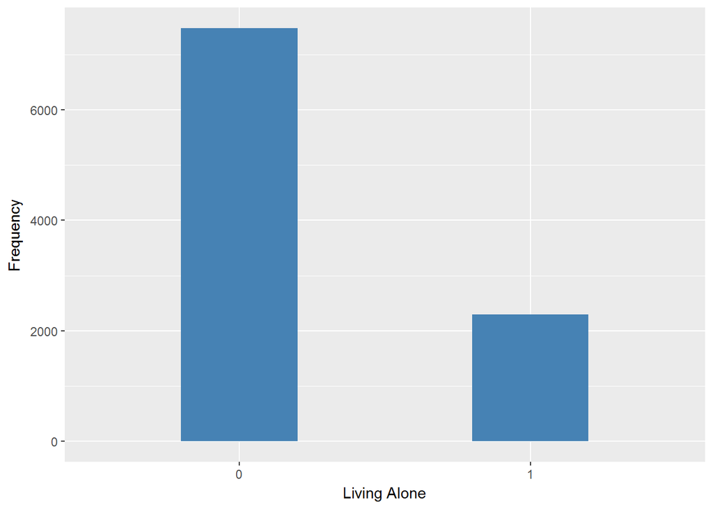

##### 2.1.3.3.1 Validation

|  | >=2->0 | 1 |
| --- | --- | --- |
| BeforeH | 7476 | 2295 |
| AfterH | 7476 | 2295 |

### 2.1.4 Wave 4

#### 2.1.4.1 Study-specific variable description

| **Name** | `npeople` |
| --- | --- |
| **Label** | `number of people in HH (adults + children)` |
| **Table name** | `wave_4_ifs_derived_variables` |
| **Description** |  |

NPEOPLE

| Sample size | Missing values |
| --- | --- |
| 11050 | 0 |

Category

|  | 1 | 2 | 3 | 4 | 5 | 6 | 7 | 8 | 9 |
| --- | --- | --- | --- | --- | --- | --- | --- | --- | --- |
| Frequency | 2582.00 | 6286.00 | 1332.00 | 602.00 | 178.00 | 54.00 | 11.0 | 3.00 | 2.00 |
| Percentage | 23.37 | 56.89 | 12.05 | 5.45 | 1.61 | 0.49 | 0.1 | 0.03 | 0.02 |

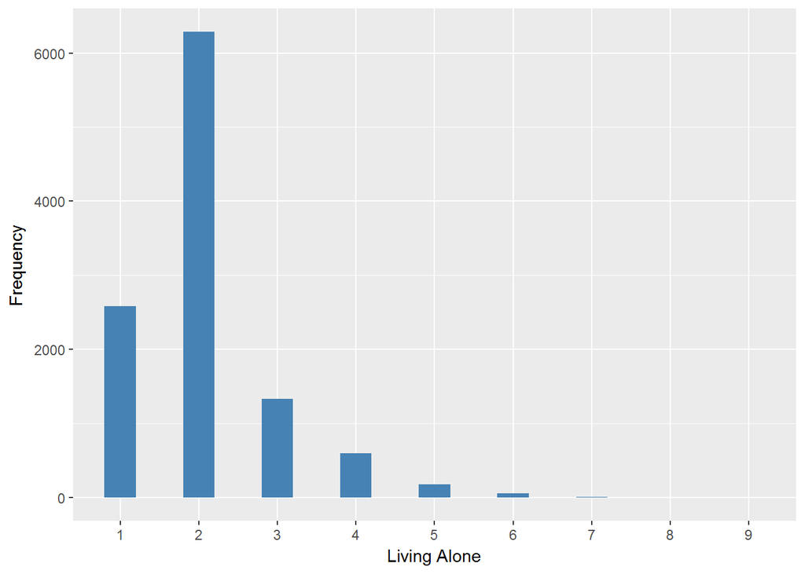

#### 2.1.4.2 Harmonisation algorithm

To compute the harmonized variable from the study-specific variable it has to be recoded as follows:

- `keep 1 into 1`
- `>1 into 0`
- `NA into 999`

**R script:**

```r
ELSA_ds_w4 <- tibble(id = ELSA_w4_la$id)
ELSA_ds_w4$living_alone <- car::recode(ELSA_w4_la$npeople, "2:hi=0 ;NA=999")
ELSA_ds_w4$living_alone <- labelled(ELSA_ds_w4$living_alone, labels = c(No = 0,
    Yes = 1, Missing = 999, `Do not know` = 998, Refuse = 997, `Not attempt not done` = 994,
    `Does not answer` = 995, `Not applicable` = 996, `Disable to measure` = 993,
    Impute = 992, `CAPI interviewer error` = 991))
```

#### 2.1.4.3 Statistics of the new harmonised variable

| Sample size | Missing values |
| --- | --- |
| 11050 | 0 |

Category

|  | 0 | 1 |
| --- | --- | --- |
| Frequency | 8468.00 | 2582.00 |
| Percentage | 76.63 | 23.37 |

Type of missing

|  | 991 | 992 | 993 | 994 | 995 | 996 | 997 | 998 | 999 | NA |
| --- | --- | --- | --- | --- | --- | --- | --- | --- | --- | --- |
| Frequency | 0 | 0 | 0 | 0 | 0 | 0 | 0 | 0 | 0 | 0 |
| Percentage | 0 | 0 | 0 | 0 | 0 | 0 | 0 | 0 | 0 | 0 |

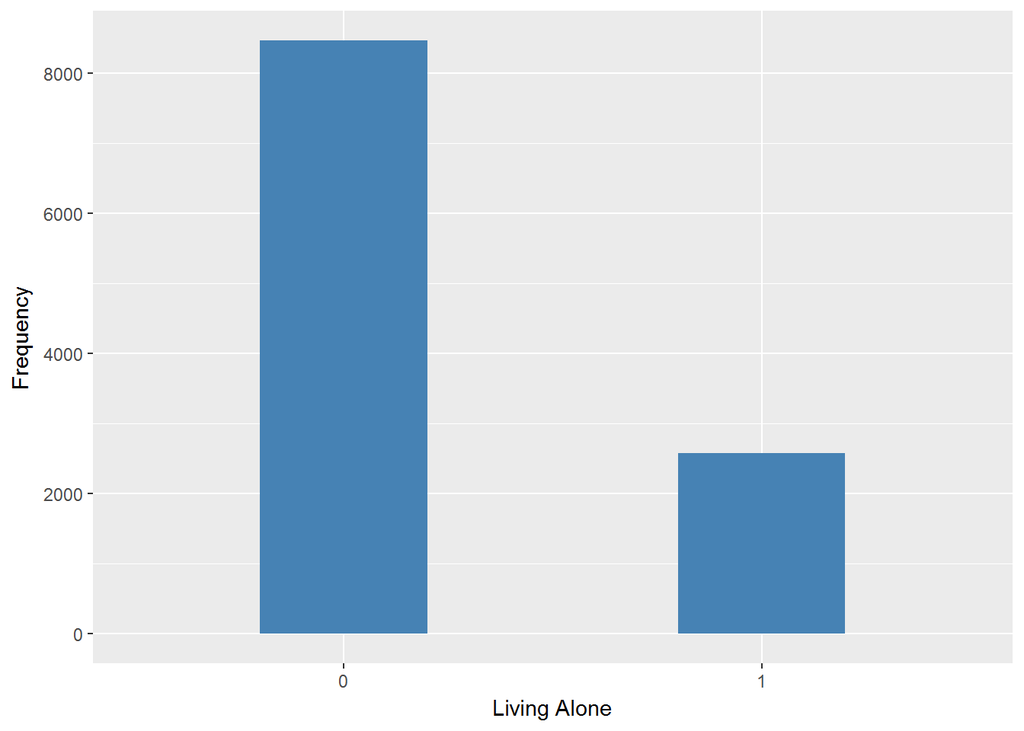

#### 2.1.4.4 Validation

|  | >=2->0 | 1 |
| --- | --- | --- |
| BeforeH | 8468 | 2582 |
| AfterH | 8468 | 2582 |

### 2.1.5 Wave 5

#### 2.1.5.1 Study-specific variable description

| **Name** | `npeople` |
| --- | --- |
| **Label** | `number of people in HH (adults + children)` |
| **Table name** | `wave_5_ifs_derived_variables` |
| **Description** |  |

NPEOPLE

| Sample size | Missing values |
| --- | --- |
| 10274 | 0 |

Category

|  | 1 | 2 | 3 | 4 | 5 | 6 | 7 | 8 | 9 |
| --- | --- | --- | --- | --- | --- | --- | --- | --- | --- |
| Frequency | 2457.00 | 5994.00 | 1197.00 | 451.00 | 119.00 | 41.0 | 5.00 | 8.00 | 2.00 |
| Percentage | 23.91 | 58.34 | 11.65 | 4.39 | 1.16 | 0.4 | 0.05 | 0.08 | 0.02 |

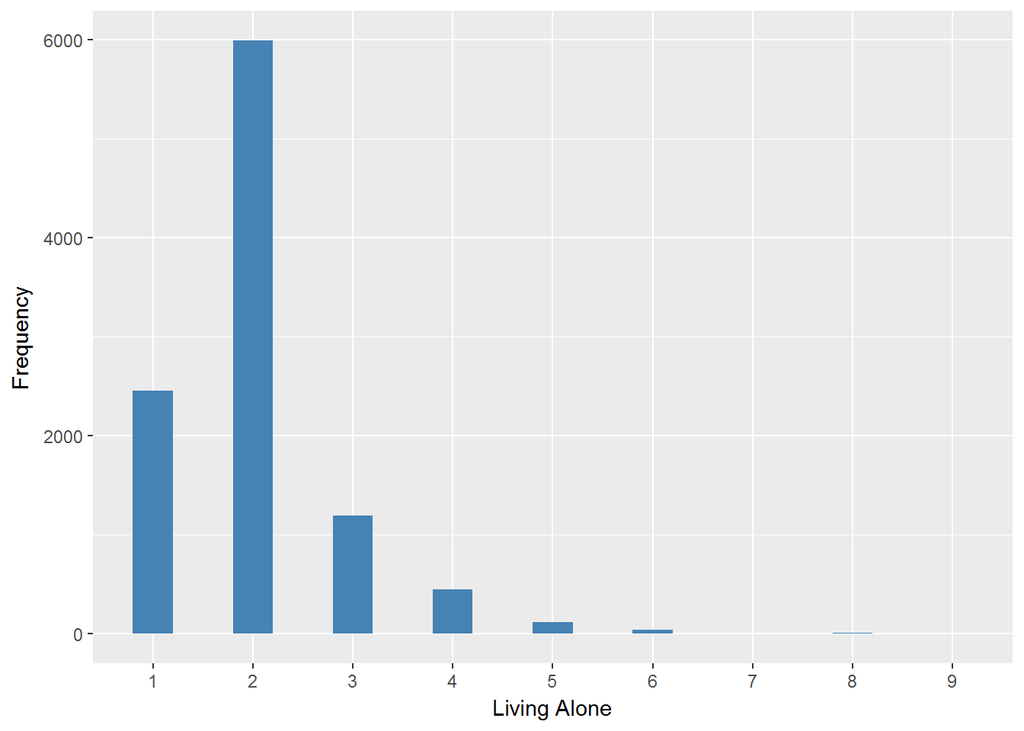

#### 2.1.5.2 Harmonisation algorithm

To compute the harmonized variable from the study-specific variable it has to be recoded as follows:

- `keep 1 into 1`
- `>1 into 0`
- `NA into 999`

**R script:**

```r
ELSA_ds_w5 <- tibble(id = ELSA_w5_la$id)
ELSA_ds_w5$living_alone <- car::recode(ELSA_w5_la$npeople, "2:hi=0 ;NA=999")
ELSA_ds_w5$living_alone <- labelled(ELSA_ds_w5$living_alone, labels = c(No = 0,
    Yes = 1, Missing = 999, `Do not know` = 998, Refuse = 997, `Not attempt not done` = 994,
    `Does not answer` = 995, `Not applicable` = 996, `Disable to measure` = 993,
    Impute = 992, `CAPI interviewer error` = 991))
```

#### 2.1.5.3 Statistics of the new harmonised variable

| Sample size | Missing values |
| --- | --- |
| 10274 | 0 |

Category

|  | 0 | 1 |
| --- | --- | --- |
| Frequency | 7817.00 | 2457.00 |
| Percentage | 76.09 | 23.91 |

Type of missing

|  | 991 | 992 | 993 | 994 | 995 | 996 | 997 | 998 | 999 | NA |
| --- | --- | --- | --- | --- | --- | --- | --- | --- | --- | --- |
| Frequency | 0 | 0 | 0 | 0 | 0 | 0 | 0 | 0 | 0 | 0 |
| Percentage | 0 | 0 | 0 | 0 | 0 | 0 | 0 | 0 | 0 | 0 |

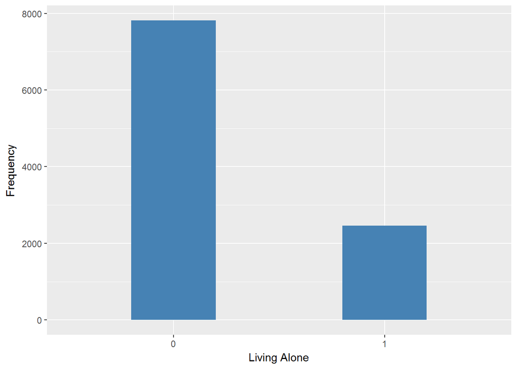

#### 2.1.5.4 Validation

|  | >=2->0 | 1 |
| --- | --- | --- |
| BeforeH | 7817 | 2457 |
| AfterH | 7817 | 2457 |

### 2.1.6 Wave 6

#### 2.1.6.1 Study-specific variable description

| **Name** | `npeople` |
| --- | --- |
| **Label** | `number of people in HH (adults + children)` |
| **Table name** | `wave_6_ifs_derived_variables` |
| **Description** |  |

NPEOPLE

| Sample size | Missing values |
| --- | --- |
| 10601 | 0 |

Category

|  | 1 | 2 | 3 | 4 | 5 | 6 | 7 | 8 | 9 |
| --- | --- | --- | --- | --- | --- | --- | --- | --- | --- |
| Frequency | 2454.00 | 6092.00 | 1227.00 | 636 | 134.00 | 42.0 | 11.0 | 4.00 | 1.00 |
| Percentage | 23.15 | 57.47 | 11.57 | 6 | 1.26 | 0.4 | 0.1 | 0.04 | 0.01 |

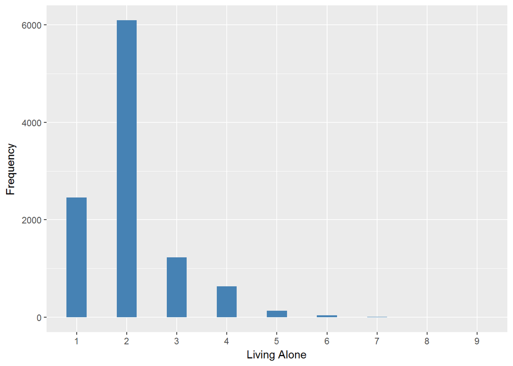

#### 2.1.6.2 Harmonisation algorithm

To compute the harmonized variable from the study-specific variable it has to be recoded as follows:

- `keep 1 into 1`
- `>1 into 0`
- `NA into 999`

**R script:**

```r
ELSA_ds_w6 <- tibble(id = ELSA_w6_la$id)
ELSA_ds_w6$living_alone <- car::recode(ELSA_w6_la$npeople, "2:hi=0 ;NA=999")
ELSA_ds_w6$living_alone <- labelled(ELSA_ds_w6$living_alone, labels = c(No = 0,
    Yes = 1, Missing = 999, `Do not know` = 998, Refuse = 997, `Not attempt not done` = 994,
    `Does not answer` = 995, `Not applicable` = 996, `Disable to measure` = 993,
    Impute = 992, `CAPI interviewer error` = 991))
```

#### 2.1.6.3 Statistics of the new harmonised variable

| Sample size | Missing values |
| --- | --- |
| 10601 | 0 |

Category

|  | 0 | 1 |
| --- | --- | --- |
| Frequency | 8147.00 | 2454.00 |
| Percentage | 76.85 | 23.15 |

Type of missing

|  | 991 | 992 | 993 | 994 | 995 | 996 | 997 | 998 | 999 | NA |
| --- | --- | --- | --- | --- | --- | --- | --- | --- | --- | --- |
| Frequency | 0 | 0 | 0 | 0 | 0 | 0 | 0 | 0 | 0 | 0 |
| Percentage | 0 | 0 | 0 | 0 | 0 | 0 | 0 | 0 | 0 | 0 |

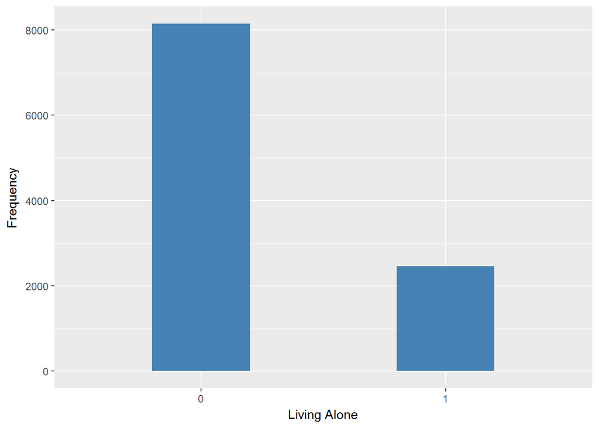

#### 2.1.6.4 Validation

|  | >=2->0 | 1 |
| --- | --- | --- |
| BeforeH | 8147 | 2454 |
| AfterH | 8147 | 2454 |

### 2.1.7 Wave 7

#### 2.1.7.1 Study-specific variable description

| **Name** | `npeople` |
| --- | --- |
| **Label** | `number of people in HH (adults + children)` |
| **Table name** | `wave7_dv` |
| **Description** |  |

npeople

| Sample size | Missing values |
| --- | --- |
| 9666 | 0 |

Category

|  | 1 | 2 | 3 | 4 | 5 | 6 | 7 | 8 |
| --- | --- | --- | --- | --- | --- | --- | --- | --- |
| Frequency | 2227.00 | 5645.0 | 1104.00 | 516.00 | 120.00 | 36.00 | 8.00 | 10.0 |
| Percentage | 23.04 | 58.4 | 11.42 | 5.34 | 1.24 | 0.37 | 0.08 | 0.1 |

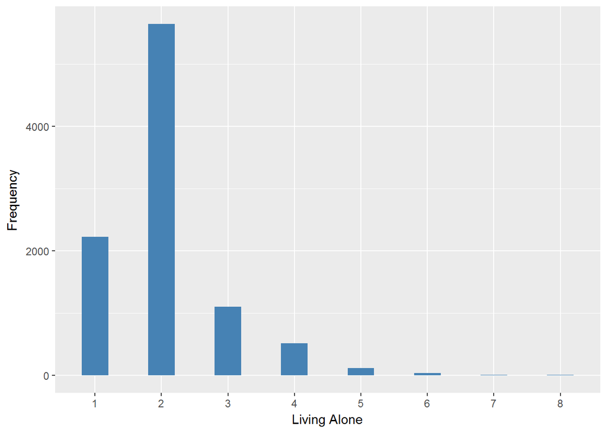

#### 2.1.7.2 Harmonisation algorithm

To compute the harmonized variable from the study-specific variable it has to be recoded as follows:

- `keep 1 into 1`
- `>1 into 0`
- `NA into 999`

**R script:**

```r
ELSA_ds_w7 <- tibble(id = ELSA_w7$id)
ELSA_ds_w7$living_alone <- car::recode(ELSA_w7$npeople, "2:hi=0 ;NA=999")
ELSA_ds_w7$living_alone <- labelled(ELSA_ds_w7$living_alone, labels = c(No = 0,
    Yes = 1, Missing = 999, `Do not know` = 998, Refuse = 997, `Not attempt not done` = 994,
    `Does not answer` = 995, `Not applicable` = 996, `Disable to measure` = 993,
    Impute = 992, `CAPI interviewer error` = 991))
```

#### 2.1.7.3 Statistics of the new harmonised variable

| Sample size | Missing values |
| --- | --- |
| 9666 | 0 |

Category

|  | 0 | 1 |
| --- | --- | --- |
| Frequency | 7439.00 | 2227.00 |
| Percentage | 76.96 | 23.04 |

Type of missing

|  | 991 | 992 | 993 | 994 | 995 | 996 | 997 | 998 | 999 | NA |
| --- | --- | --- | --- | --- | --- | --- | --- | --- | --- | --- |
| Frequency | 0 | 0 | 0 | 0 | 0 | 0 | 0 | 0 | 0 | 0 |
| Percentage | 0 | 0 | 0 | 0 | 0 | 0 | 0 | 0 | 0 | 0 |

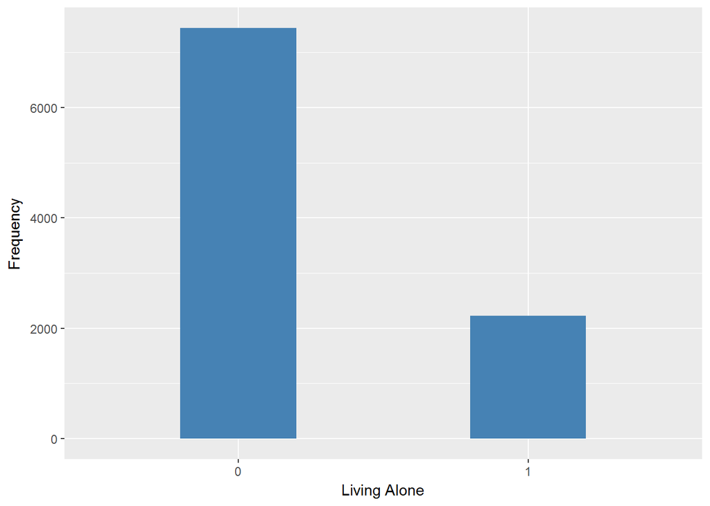

#### 2.1.7.4 Validation

|  | >=2->0 | 1 |
| --- | --- | --- |
| BeforeH | 7439 | 2227 |
| AfterH | 7439 | 2227 |

# 3 Quality estimation

No comments.